# Trucking deregulation

Mohsen Bahremani

11/23/2020

```r
library(ggplot2)
library(dplyr)
library(tidyverse)
library(ISLR)
library(corrgram)
library(car)
df<-read.csv('trucking.csv')
set.seed(1) #Ensure reproducible code
df=df[,-c(6)]
head(df)
```

```
##          Y   x1    x2 x3 x4
## 1  9.90057 3.60  7.50  1  1
## 2 11.62770 0.25  7.50  1  1
## 3 11.19784 0.25 15.00  1  1
## 4 10.64285 0.25 24.00  1  1
## 5 10.06555 2.60  7.50  1  1
## 6 10.97200 1.50  0.25  1  1
```

```r
str(df)
```

```
## 'data.frame':    134 obs. of  5 variables:
##  $ Y : num  9.9 11.6 11.2 10.6 10.1 ...
##  $ x1: num  3.6 0.25 0.25 0.25 2.6 1.5 4.8 4.8 6 3 ...
##  $ x2: num  7.5 7.5 15 24 7.5 0.25 0.25 7.5 24 0.25 ...
##  $ x3: int  1 1 1 1 1 1 1 1 1 1 ...
##  $ x4: int  1 1 1 1 1 1 1 1 1 0 ...
```

```r
summary(df)
```

```
##        Y               x1              x2               x3
##  Min.   : 8.68   Min.   :0.250   Min.   : 0.250   Min.   :0.0
##  1st Qu.:10.12   1st Qu.:1.875   1st Qu.: 0.750   1st Qu.:0.0
##  Median :10.52   Median :3.000   Median : 7.500   Median :0.5
##  Mean   :10.58   Mean   :2.931   Mean   : 9.082   Mean   :0.5
##  3rd Qu.:11.14   3rd Qu.:3.600   3rd Qu.:15.000   3rd Qu.:1.0
##  Max.   :12.97   Max.   :6.000   Max.   :24.000   Max.   :1.0
##        x4
##  Min.   :0.0000
##  1st Qu.:0.0000
##  Median :1.0000
##  Mean   :0.5299
##  3rd Qu.:1.0000
##  Max.   :1.0000
```

```r
summary(is.na(df))
```

```
##      Y               x1              x2              x3
##  Mode :logical   Mode :logical   Mode :logical   Mode :logical
##  FALSE:134       FALSE:134       FALSE:134       FALSE:134
##      x4
##  Mode :logical
##  FALSE:134
```

Investigate the data types in data frame (df) data structure to ensure no changes is required. Investigate if there are any missing values (NA) in each variables. For this dataset, luckily is quited clean.

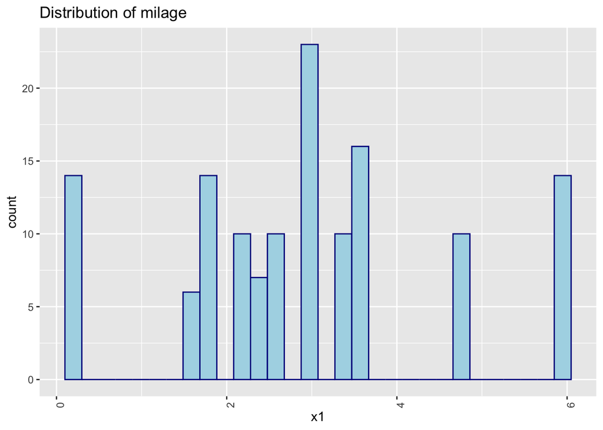

```r
ggplot(df,aes(x=x1))+geom_histogram(color='darkblue', fill='lightblue') + theme(axis.text.x= element_text(angle=90,hjust=1)) + ggtitle("Distribution of milage")
```

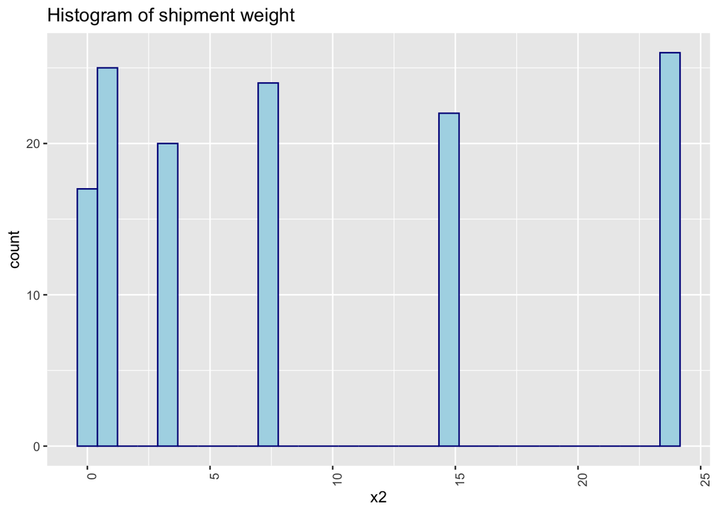

```r
ggplot(df,aes(x=x2))+geom_histogram(color='darkblue', fill='lightblue') + theme(axis.text.x= element_text(angle=90,hjust=1)) + ggtitle("Histogram of shipment weight")
```

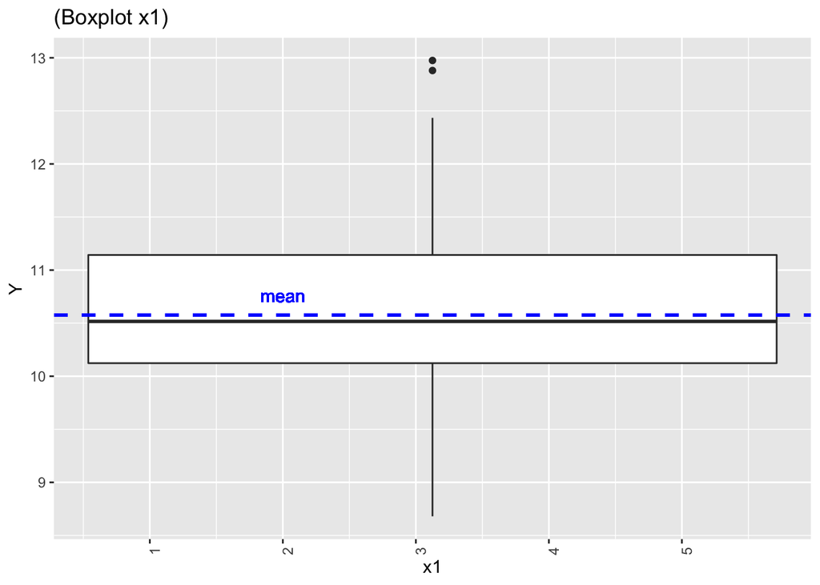

```r
ggplot(data=df, aes(x=x1, y=Y)) + geom_boxplot() +ggtitle('(Boxplot x1)') + theme(axis.text.x= element_text(angle=90,hjust=1))+
geom_hline(aes(yintercept=mean(Y)),color="blue", linetype="dashed",size=1, alpha = 1) + geom_text(aes(2,mean(Y),label = 'mean', vjust = -1),color='blue')
```

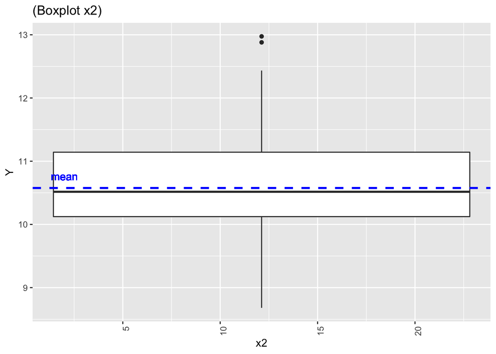

```r
ggplot(data=df, aes(x=x2, y=Y)) + geom_boxplot() +ggtitle('(Boxplot x2)') + theme(axis.text.x= element_text(angle=90,hjust=1))+
geom_hline(aes(yintercept=mean(Y)),color="blue", linetype="dashed",size=1, alpha = 1) + geom_text(aes(2,mean(Y),label = 'mean', vjust = -1),color='blue')
```

Two outliers are indentified, but at this moment we ignore them.

```r
#corrgram(df[,c(1,2,3)], order=TRUE, upper.panel=panel.cor)
library(PerformanceAnalytics)
```

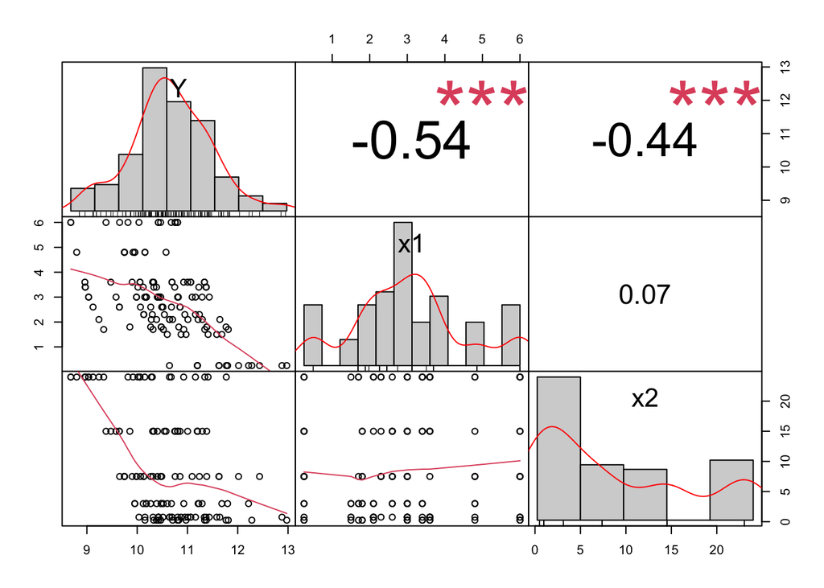

```r
chart.Correlation(df[,c(1,2,3)], histogram = TRUE, pch = 19)
```

There is no collinarity as this dataset, because of the low correlation between x1 and x2.

## Full model

```r
fullmodel=lm(Y~x1+x2+x1*x2+I(x1^2)+I(x2^2)+x3+x4+x3*x4+x1*x3+x1*x4+x1*x3*x4+x2*x3+x2*x4+x2*x3*x4+x1*x2*x3+x1*x2*x4+x1*x2*x3*x4+I(x1^2)*x3+I(x1^2)*x4+I(x1^2)*x3*x4+I(x2^2)*x3+I(x2^2)*x4+I(x2^2)*x3*x4, data=df)
summary(fullmodel)
```

```
##
## Call:
## lm(formula = Y ~ x1 + x2 + x1 * x2 + I(x1^2) + I(x2^2) + x3 +
##     x4 + x3 * x4 + x1 * x3 + x1 * x4 + x1 * x3 * x4 + x2 * x3 +
##     x2 * x4 + x2 * x3 * x4 + x1 * x2 * x3 + x1 * x2 * x4 + x1 *
##     x2 * x3 * x4 + I(x1^2) * x3 + I(x1^2) * x4 + I(x1^2) * x3 *
##     x4 + I(x2^2) * x3 + I(x2^2) * x4 + I(x2^2) * x3 * x4, data = df)
##
## Residuals:
##      Min       1Q   Median       3Q      Max
## -0.56177 -0.11494  0.01703  0.13503  0.53108
##
## Coefficients:
##                 Estimate Std. Error t value Pr(>|t|)
## (Intercept)   12.5159255  0.9544078  13.114  < 2e-16 ***
## x1            -0.8992352  0.7340967  -1.225  0.22321
## x2             0.0242058  0.0288601   0.839  0.40344
## I(x1^2)        0.1514495  0.1345547   1.126  0.26280
## I(x2^2)       -0.0001020  0.0007696  -0.132  0.89484
## x3            -1.1264698  1.4910420  -0.755  0.45157
## x4             0.2761535  0.9633188   0.287  0.77491
## x1:x2         -0.0207086  0.0067322  -3.076  0.00265 **
## x3:x4          0.4969384  1.5028968   0.331  0.74154
## x1:x3          0.4820356  1.1588177   0.416  0.67824
## x1:x4          0.0695849  0.7388178   0.094  0.92513
## x2:x3         -0.0948598  0.0447665  -2.119  0.03634 *
## x2:x4         -0.0526154  0.0352795  -1.491  0.13872
## I(x1^2):x3    -0.1167365  0.2191796  -0.533  0.59538
## I(x1^2):x4    -0.0727599  0.1350949  -0.539  0.59126
## I(x2^2):x3     0.0004376  0.0011854   0.369  0.71273
## I(x2^2):x4     0.0001110  0.0010677   0.104  0.91741
## x1:x3:x4      -0.5403501  1.1643979  -0.464  0.64352
## x2:x3:x4       0.0682622  0.0522032   1.308  0.19373
## x1:x2:x3       0.0220726  0.0107753   2.048  0.04290 *
## x1:x2:x4       0.0235486  0.0070932   3.320  0.00122 **
## I(x1^2):x3:x4  0.1342343  0.2198412   0.611  0.54273
## I(x2^2):x3:x4 -0.0002760  0.0015707  -0.176  0.86085
## x1:x2:x3:x4   -0.0269383  0.0112668  -2.391  0.01850 *
## ---
## Signif. codes:  0 '***' 0.001 '**' 0.01 '*' 0.05 '.' 0.1 ' ' 1
##
## Residual standard error: 0.2358 on 110 degrees of freedom
## Multiple R-squared:  0.932,  Adjusted R-squared:  0.9178
## F-statistic: 65.59 on 23 and 110 DF,  p-value: < 2.2e-16
```

```r
anova(fullmodel)
```

```
## Analysis of Variance Table
##
## Response: Y
##                Df  Sum Sq Mean Sq  F value    Pr(>F)
## x1              1 26.7309 26.7309 480.5679 < 2.2e-16 ***
## x2              1 14.9211 14.9211 268.2523 < 2.2e-16 ***
## I(x1^2)         1  7.8506  7.8506 141.1377 < 2.2e-16 ***
## I(x2^2)         1  0.0460  0.0460   0.8264   0.36531
## x3              1 30.4780 30.4780 547.9333 < 2.2e-16 ***
## x4              1  0.0330  0.0330   0.5936   0.44270
## x1:x2           1  0.0060  0.0060   0.1076   0.74356
## x3:x4           1  0.0078  0.0078   0.1400   0.70904
## x1:x3           1  0.0222  0.0222   0.3983   0.52929
## x1:x4           1  0.2885  0.2885   5.1861   0.02470 *
## x2:x3           1  2.3431  2.3431  42.1251 2.541e-09 ***
## x2:x4           1  0.2845  0.2845   5.1147   0.02569 *
## I(x1^2):x3      1  0.0383  0.0383   0.6884   0.40849
## I(x1^2):x4      1  0.0028  0.0028   0.0495   0.82437
## I(x2^2):x3      1  0.0006  0.0006   0.0105   0.91853
## I(x2^2):x4      1  0.0196  0.0196   0.3523   0.55402
## x1:x3:x4        1  0.0276  0.0276   0.4965   0.48255
## x2:x3:x4        1  0.1433  0.1433   2.5768   0.11131
## x1:x2:x3        1  0.0281  0.0281   0.5049   0.47886
## x1:x2:x4        1  0.3062  0.3062   5.5054   0.02075 *
## I(x1^2):x3:x4   1  0.0134  0.0134   0.2413   0.62426
## I(x2^2):x3:x4   1  0.0000  0.0000   0.0005   0.98154
## x1:x2:x3:x4     1  0.3180  0.3180   5.7166   0.01850 *
## Residuals     110  6.1186  0.0556
## ---
## Signif. codes:  0 '***' 0.001 '**' 0.01 '*' 0.05 '.' 0.1 ' ' 1
```

Initially, we tried to model “the price charged per ton-mile” at full dimention of the second order model contains quadratic (curvature) terms for quantitative variables and interactions among the quantitative and qualitative terms. The R_squared is reasonable (0.932).

## Model improvement

```r
library(leaps)
leaps.ck <- function (X, Y, nbest =3)
{

  leaps.out <- leaps(X,Y,method="Cp",nbest=nbest)

  leaps.mat <- cbind(leaps.out$size,round(leaps.out$Cp,digits=4))

  colnames(leaps.mat) <- c("k","C_k")

  leaps.mat <- cbind(leaps.out$which, leaps.mat)

  return(leaps.mat)

}

leaps.ck(df[,c(2,3,4,5)],df$Y)
```

```
##   1 2 3 4 k      C_k
## 1 1 0 0 0 2 421.3131
## 1 0 0 1 0 2 437.1406
## 1 0 1 0 0 2 499.5065
## 2 1 0 1 0 3 178.1397
## 2 0 1 1 0 3 263.6877
## 2 1 1 0 0 3 293.3513
## 3 1 1 1 0 4  31.4050
## 3 1 0 1 1 4 153.3363
## 3 0 1 1 1 4 250.8187
## 4 1 1 1 1 5   5.0000
```

we tried to check it by Forward feature selection.

```r
result.null <- lm(Y~1, data=df)
step(result.null,scope=list(lower=result.null,upper=fullmodel),direction="forward",verbose=FALSE)
```

```
## Start:  AIC=-51.29
## Y ~ 1
##
##           Df Sum of Sq    RSS     AIC
## + x1       1   26.7309 63.297 -96.500
## + x3       1   24.9137 65.114 -92.707
## + x2       1   17.7533 72.275 -78.727
## + I(x2^2)  1   17.2608 72.767 -77.817
## + I(x1^2)  1   16.9621 73.066 -77.268
## <none>                 90.028 -51.294
## + x4       1    0.4802 89.548 -50.011
##
## Step:  AIC=-96.5
## Y ~ x1
##
##           Df Sum of Sq    RSS      AIC
## + x3       1   28.1488 35.148 -173.327
## + x2       1   14.9211 48.376 -130.524
## + I(x2^2)  1   13.7931 49.504 -127.435
## + I(x1^2)  1    7.0713 56.226 -110.374
## + x4       1    1.3387 61.958  -97.364
## <none>                 63.297  -96.500
##
## Step:  AIC=-173.33
## Y ~ x1 + x3
##
##           Df Sum of Sq    RSS     AIC
## + x2       1   17.0765 18.072 -260.47
## + I(x2^2)  1   16.1330 19.015 -253.65
## + I(x1^2)  1    7.2178 27.931 -202.13
## + x4       1    3.0773 32.071 -183.60
## <none>                 35.148 -173.33
## + x1:x3    1    0.2731 34.875 -172.37
##
## Step:  AIC=-260.47
## Y ~ x1 + x3 + x2
##
##           Df Sum of Sq    RSS     AIC
## + I(x1^2)  1    8.0680 10.004 -337.71
## + x4       1    3.2612 14.811 -285.13
```

[output cut: 13 more lines]

```
## + x1:x3       1   0.01414  9.9898 -335.90
## + x1:x2       1   0.00770  9.9962 -335.81
## + I(x2^2)     1   0.00240 10.0015 -335.74
## + I(x1^2):x3  1   0.00202 10.0019 -335.74
##
## Step:  AIC=-369.01
## Y ~ x1 + x3 + x2 + I(x1^2) + x3:x2
##
##              Df Sum of Sq    RSS     AIC
## <none>                    7.8028 -369.01
## + I(x2^2)     1 0.0097475 7.7931 -367.18
## + I(x1^2):x3  1 0.0092363 7.7936 -367.17
## + x4          1 0.0049548 7.7979 -367.09
## + x1:x2       1 0.0025745 7.8003 -367.05
## + x1:x3       1 0.0000165 7.8028 -367.01
```

```
##
## Call:
## lm(formula = Y ~ x1 + x3 + x2 + I(x1^2) + x3:x2, data = df)
##
## Coefficients:
## (Intercept)           x1           x3           x2      I(x1^2)        x3:x2
##    12.78831     -0.81742     -0.69191     -0.02794      0.08291     -0.02933
```

```r
step(fullmodel,direction="backward",verbose=FALSE)
```

```
## Start:  AIC=-365.59
## Y ~ x1 + x2 + x1 * x2 + I(x1^2) + I(x2^2) + x3 + x4 + x3 * x4 +
##     x1 * x3 + x1 * x4 + x1 * x3 * x4 + x2 * x3 + x2 * x4 + x2 *
##     x3 * x4 + x1 * x2 * x3 + x1 * x2 * x4 + x1 * x2 * x3 * x4 +
##     I(x1^2) * x3 + I(x1^2) * x4 + I(x1^2) * x3 * x4 + I(x2^2) *
##     x3 + I(x2^2) * x4 + I(x2^2) * x3 * x4
##
##                 Df Sum of Sq    RSS     AIC
## - I(x2^2):x3:x4  1   0.00172 6.1203 -367.55
## - I(x1^2):x3:x4  1   0.02074 6.1393 -367.14
## <none>                       6.1186 -365.59
## - x1:x2:x3:x4    1   0.31798 6.4366 -360.80
##
## Step:  AIC=-367.55
## Y ~ x1 + x2 + I(x1^2) + I(x2^2) + x3 + x4 + x1:x2 + x3:x4 + x1:x3 +
##     x1:x4 + x2:x3 + x2:x4 + I(x1^2):x3 + I(x1^2):x4 + I(x2^2):x3 +
##     I(x2^2):x4 + x1:x3:x4 + x2:x3:x4 + x1:x2:x3 + x1:x2:x4 +
##     I(x1^2):x3:x4 + x1:x2:x3:x4
##
##                 Df Sum of Sq    RSS     AIC
## - I(x2^2):x4     1   0.00002 6.1203 -369.55
## - I(x2^2):x3     1   0.00723 6.1275 -369.40
## - I(x1^2):x3:x4  1   0.02013 6.1404 -369.11
## <none>                       6.1203 -367.55
## - x1:x2:x3:x4    1   0.31629 6.4366 -362.80
##
## Step:  AIC=-369.55
## Y ~ x1 + x2 + I(x1^2) + I(x2^2) + x3 + x4 + x1:x2 + x3:x4 + x1:x3 +
##     x1:x4 + x2:x3 + x2:x4 + I(x1^2):x3 + I(x1^2):x4 + I(x2^2):x3 +
##     x1:x3:x4 + x2:x3:x4 + x1:x2:x3 + x1:x2:x4 + I(x1^2):x3:x4 +
##     x1:x2:x3:x4
##
##                 Df Sum of Sq    RSS     AIC
## - I(x2^2):x3     1   0.00721 6.1275 -371.40
## - I(x1^2):x3:x4  1   0.02064 6.1410 -371.10
## <none>                       6.1203 -369.55
## - x1:x2:x3:x4    1   0.31735 6.4377 -364.78
##
## Step:  AIC=-371.4
## Y ~ x1 + x2 + I(x1^2) + I(x2^2) + x3 + x4 + x1:x2 + x3:x4 + x1:x3 +
```

[output cut: 34 more lines]

```
##
##               Df Sum of Sq    RSS     AIC
## - I(x1^2):x3   1  0.052005 6.2056 -377.70
## <none>                     6.1536 -376.83
## - x1:x2:x3:x4  1  0.307753 6.4613 -372.29
##
## Step:  AIC=-377.7
## Y ~ x1 + x2 + I(x1^2) + x3 + x4 + x1:x2 + x3:x4 + x1:x3 + x1:x4 +
##     x2:x3 + x2:x4 + x1:x3:x4 + x2:x3:x4 + x1:x2:x3 + x1:x2:x4 +
##     x1:x2:x3:x4
##
##               Df Sum of Sq     RSS     AIC
## <none>                      6.2056 -377.70
## - x1:x2:x3:x4  1    0.3049  6.5105 -373.27
## - I(x1^2)      1    5.9712 12.1767 -289.37
```

```
##
## Call:
## lm(formula = Y ~ x1 + x2 + I(x1^2) + x3 + x4 + x1:x2 + x3:x4 +
##     x1:x3 + x1:x4 + x2:x3 + x2:x4 + x1:x3:x4 + x2:x3:x4 + x1:x2:x3 +
##     x1:x2:x4 + x1:x2:x3:x4, data = df)
##
## Coefficients:
## (Intercept)           x1           x2      I(x1^2)           x3           x4
##    12.07898     -0.55236      0.02122      0.08742     -0.38615      0.76094
##       x1:x2        x3:x4        x1:x3        x1:x4        x2:x3        x2:x4
##    -0.02057     -0.35075     -0.13145     -0.33441     -0.08268     -0.04865
##    x1:x3:x4     x2:x3:x4     x1:x2:x3     x1:x2:x4  x1:x2:x3:x4
##     0.18155      0.05919      0.02144      0.02335     -0.02602
```

```r
step(result.null,scope=list(upper=fullmodel),direction="both",verbose=FALSE)
```

```
## Start:  AIC=-51.29
## Y ~ 1
##
##           Df Sum of Sq    RSS     AIC
## + x1       1   26.7309 63.297 -96.500
## + x3       1   24.9137 65.114 -92.707
## + x2       1   17.7533 72.275 -78.727
## + I(x2^2)  1   17.2608 72.767 -77.817
## + I(x1^2)  1   16.9621 73.066 -77.268
## <none>                 90.028 -51.294
## + x4       1    0.4802 89.548 -50.011
##
## Step:  AIC=-96.5
## Y ~ x1
##
##           Df Sum of Sq    RSS      AIC
## + x3       1   28.1488 35.148 -173.327
## + x2       1   14.9211 48.376 -130.524
## + I(x2^2)  1   13.7931 49.504 -127.435
## + I(x1^2)  1    7.0713 56.226 -110.374
## + x4       1    1.3387 61.958  -97.364
## <none>                 63.297  -96.500
## - x1       1   26.7309 90.028  -51.294
##
## Step:  AIC=-173.33
## Y ~ x1 + x3
##
##           Df Sum of Sq    RSS      AIC
## + x2       1   17.0765 18.072 -260.466
## + I(x2^2)  1   16.1330 19.015 -253.647
## + I(x1^2)  1    7.2178 27.931 -202.128
## + x4       1    3.0773 32.071 -183.605
## <none>                 35.148 -173.327
## + x1:x3    1    0.2731 34.875 -172.372
## - x3       1   28.1488 63.297  -96.500
## - x1       1   29.9659 65.114  -92.707
##
## Step:  AIC=-260.47
## Y ~ x1 + x3 + x2
##
```

[output cut: 26 more lines]

```
## - x3          1   30.5215 40.525 -152.25
##
## Step:  AIC=-369.01
## Y ~ x1 + x3 + x2 + I(x1^2) + x3:x2
##
##              Df Sum of Sq     RSS     AIC
## <none>                     7.8028 -369.01
## + I(x2^2)     1    0.0097  7.7931 -367.18
## + I(x1^2):x3  1    0.0092  7.7936 -367.17
## + x4          1    0.0050  7.7979 -367.09
## + x1:x2       1    0.0026  7.8003 -367.05
## + x1:x3       1    0.0000  7.8028 -367.01
## - x3:x2       1    2.2011 10.0039 -337.71
## - I(x1^2)     1    8.8931 16.6959 -269.08
## - x1          1   19.4658 27.2686 -203.34
```

```
##
## Call:
## lm(formula = Y ~ x1 + x3 + x2 + I(x1^2) + x3:x2, data = df)
##
## Coefficients:
## (Intercept)           x1           x3           x2      I(x1^2)        x3:x2
##    12.78831     -0.81742     -0.69191     -0.02794      0.08291     -0.02933
```

```r
model1=lm(Y~  x1 +  x3   +   x2   + I(x1^2)  +  x3*x2 ,data=df)
model2=lm(Y~x1+x2+I(x1^2) +x3 + x4+ x1*x2 +x3*x4+ x1*x3 +  x1*x4 + x2*x3 +  x2*x4 + x1*x3*x4 + x2*x3*x4 + x1*x2*x3 + x1*x2*x4+x1*x2*x3*x4 ,data=df)
summary(model1)
```

```
##
## Call:
## lm(formula = Y ~ x1 + x3 + x2 + I(x1^2) + x3 * x2, data = df)
##
## Residuals:
##      Min       1Q   Median       3Q      Max
## -0.62713 -0.18405  0.02164  0.14091  0.67491
##
## Coefficients:
##              Estimate Std. Error t value Pr(>|t|)
## (Intercept) 12.788306   0.078562 162.779  < 2e-16 ***
## x1          -0.817415   0.045743 -17.870  < 2e-16 ***
## x3          -0.691914   0.061502 -11.250  < 2e-16 ***
## x2          -0.027939   0.003334  -8.379 8.17e-14 ***
## I(x1^2)      0.082910   0.006864  12.078  < 2e-16 ***
## x3:x2       -0.029332   0.004881  -6.009 1.81e-08 ***
## ---
## Signif. codes:  0 '***' 0.001 '**' 0.01 '*' 0.05 '.' 0.1 ' ' 1
##
## Residual standard error: 0.2469 on 128 degrees of freedom
## Multiple R-squared:  0.9133, Adjusted R-squared:  0.9099
## F-statistic: 269.8 on 5 and 128 DF,  p-value: < 2.2e-16
```

```r
summary(model2)
```

```
##
## Call:
## lm(formula = Y ~ x1 + x2 + I(x1^2) + x3 + x4 + x1 * x2 + x3 *
##     x4 + x1 * x3 + x1 * x4 + x2 * x3 + x2 * x4 + x1 * x3 * x4 +
##     x2 * x3 * x4 + x1 * x2 * x3 + x1 * x2 * x4 + x1 * x2 * x3 *
##     x4, data = df)
##
## Residuals:
##      Min       1Q   Median       3Q      Max
## -0.59167 -0.10185  0.01949  0.12332  0.56158
##
## Coefficients:
##              Estimate Std. Error t value Pr(>|t|)
## (Intercept) 12.078979   0.256288  47.131  < 2e-16 ***
## x1          -0.552358   0.096049  -5.751 7.22e-08 ***
## x2           0.021224   0.018253   1.163 0.247277
## I(x1^2)      0.087419   0.008239  10.610  < 2e-16 ***
## x3          -0.386146   0.398431  -0.969 0.334461
## x4           0.760944   0.270237   2.816 0.005711 **
## x1:x2       -0.020567   0.006421  -3.203 0.001753 **
## x3:x4       -0.350751   0.424730  -0.826 0.410586
## x1:x3       -0.131449   0.141135  -0.931 0.353580
## x1:x4       -0.334406   0.089533  -3.735 0.000292 ***
## x2:x3       -0.082676   0.029440  -2.808 0.005838 **
## x2:x4       -0.048649   0.020346  -2.391 0.018395 *
## x1:x3:x4     0.181546   0.146832   1.236 0.218779
## x2:x3:x4     0.059190   0.032026   1.848 0.067099 .
## x1:x2:x3     0.021438   0.010381   2.065 0.041121 *
## x1:x2:x4     0.023351   0.006782   3.443 0.000798 ***
## x1:x2:x3:x4 -0.026018   0.010852  -2.398 0.018083 *
## ---
## Signif. codes:  0 '***' 0.001 '**' 0.01 '*' 0.05 '.' 0.1 ' ' 1
##
## Residual standard error: 0.2303 on 117 degrees of freedom
## Multiple R-squared:  0.9311, Adjusted R-squared:  0.9216
## F-statistic: 98.77 on 16 and 117 DF,  p-value: < 2.2e-16
```

```r
anova(model1,fullmodel)
```

```
## Analysis of Variance Table
##
## Model 1: Y ~ x1 + x3 + x2 + I(x1^2) + x3 * x2
## Model 2: Y ~ x1 + x2 + x1 * x2 + I(x1^2) + I(x2^2) + x3 + x4 + x3 * x4 +
##     x1 * x3 + x1 * x4 + x1 * x3 * x4 + x2 * x3 + x2 * x4 + x2 *
##     x3 * x4 + x1 * x2 * x3 + x1 * x2 * x4 + x1 * x2 * x3 * x4 +
##     I(x1^2) * x3 + I(x1^2) * x4 + I(x1^2) * x3 * x4 + I(x2^2) *
##     x3 + I(x2^2) * x4 + I(x2^2) * x3 * x4
##   Res.Df    RSS Df Sum of Sq      F  Pr(>F)
## 1    128 7.8028
## 2    110 6.1186 18    1.6843 1.6822 0.05315 .
## ---
## Signif. codes:  0 '***' 0.001 '**' 0.01 '*' 0.05 '.' 0.1 ' ' 1
```

```r
anova(model2,fullmodel)
```

```
## Analysis of Variance Table
##
## Model 1: Y ~ x1 + x2 + I(x1^2) + x3 + x4 + x1 * x2 + x3 * x4 + x1 * x3 +
##     x1 * x4 + x2 * x3 + x2 * x4 + x1 * x3 * x4 + x2 * x3 * x4 +
##     x1 * x2 * x3 + x1 * x2 * x4 + x1 * x2 * x3 * x4
## Model 2: Y ~ x1 + x2 + x1 * x2 + I(x1^2) + I(x2^2) + x3 + x4 + x3 * x4 +
##     x1 * x3 + x1 * x4 + x1 * x3 * x4 + x2 * x3 + x2 * x4 + x2 *
##     x3 * x4 + x1 * x2 * x3 + x1 * x2 * x4 + x1 * x2 * x3 * x4 +
##     I(x1^2) * x3 + I(x1^2) * x4 + I(x1^2) * x3 * x4 + I(x2^2) *
##     x3 + I(x2^2) * x4 + I(x2^2) * x3 * x4
##   Res.Df    RSS Df Sum of Sq      F Pr(>F)
## 1    117 6.2056
## 2    110 6.1186  7  0.086973 0.2234 0.9791
```

The nested analysis showed us the both of the reduced models are significant than full model. Therefore, we continued with reduced models.

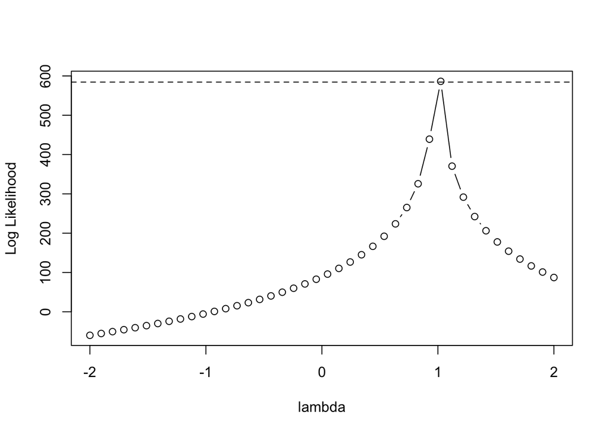

```r
### Modified Box-Cox transformation ###
box.cox <- function(x,y,intercept=TRUE, ylim=NULL,
                   lambda =seq (-2, 2, len=42), transform.x=FALSE,verbose =TRUE, make.plot=TRUE)
# Applies Box-Cox transformation to y with parameter values lambda,
# prints the fitted regressions, makes a plot of the log likelihood versus lambda, and returns a
# vector containing the log likelihood values, normalized for the transformation, for each lambda.
# x - X matrix for current model (no column of 1's should be included for an intercept term);
# y - Y vector.
# intercept - Set to FALSE for a no-intercept model.
# ylim - The range of log-likelihood values on the y-axis (if NULL, then use range(y)).
#        Useful if you want to use the same scale for two plots.
# lambda - Y is raised to the power lambda. For log(Y) set lambda=0.
# transform.x - Apply the same transformation to all elements of x?
# verbose - Print fitted regression for each lambda?
# make.plot - Make the plot?

{  # Use only cases where y > 0 - otherwise geometric mean undefined.
     good.cases <- (y>0)
     y <- y[good.cases]
     x <- as.matrix(x)
     x <- x[good.cases, , drop=F]


     # Geometric mean of y.
     g <- exp(mean(log(y)))

     if(transform.x)
     {

        # An x column will only be transformed if all values
        # are positive.
        x.pos <- vector(mode= "logical", length=ncol(x))
        for(j in 1:ncol(x))
           x.pos[j] <- (min(x[j]) > 0)
           x.name <- dimnames(x)[[2]]
         if( mode(x.name)=="NULL")
           x.name <- paste("X",1:ncol(x),sep="")
     }

   log.lik <- vector(mode ="numeric",length=length(lambda))

   for(i in 1:length(lambda))
  {
     if(lambda[i] !=0)
      {
         # Don't apply constants. In particular, subtracting
         # 1.0 would introduce intercept in no-intercept model.
         # Normalizations aplied to SS(Res) later.
         z <- y^lambda[i]
         if (transform.x)
       {
          x.new <- x
          x.new.name <- x.name
           for(j in 1:ncol(x))
              if(x.pos[j])
              {
                 x.new[,j] <- x[,j]^lambda[i]
                 x.new.name[j] <- paste(x.name[j],"^",lambda[i], sep="")
          }

    }

 }

  else
  {
          z<- log(y)
          if(transform.x)
           {
             x.new <- x
             x.new.name <- x.name
              for(j in 1:ncol(x))
                  if(x.pos[j])
                 {
                     x.new[,j] <- log(x[,j])
                     x.new.name[j] <- paste("log(",x.name[j],")",sep="")
                }
           }

      }

  if(transform.x)
  {
       dimnames(x.new) <- list(NULL,x.new.name)
       reg <- lsfit(x.new,z,intercept=intercept)
   }
  else
       reg <- lsfit(x,z,intercept = intercept)

  if(verbose)
 { cat("Lambda:",lambda[i], "\n")
   ls.print(reg)
 }

 res <- reg$residuals
 ss.res <- sum(res^2)/g^(2.0*(lambda[i] - 1.0 ))
 if (lambda[i] !=0.0)
  ss.res <- ss.res/lambda[i]^2
 log.lik[i] <- -length(y)/2.0*log(ss.res)
 }

if(make.plot)
{
 if(mode(ylim)=="NULL")
   ylim <- range(log.lik)
   plot(lambda,log.lik,ylim=ylim, ylab="Log Likelihood", type="b", lty=1)
   abline(max(log.lik)-3.8416/2,0,lty=2)
 }

return(log.lik)

}
result=box.cox(df[1:4],df$Y, verbose = FALSE) # the function returns the log-liklihood values.
```

```r
lambda_seq = seq (-2, 2,len=42) # This sequence is taken from the function above.
optimal_lambda = lambda_seq[which.max(result)]
```

The respose variable is logarithmic, as it describe in the question. The box-cox algorithm confirm that the variables do not need to any transformation.

## Model Diagnostics

[figure not shown]

```r
par(mfrow = c(2,2))
plot(df$x1, model1$reiduals , xlab ="X1" , ylab= "Residuals", main = "   Residuals vs x")
plot(df$x2, model1$reiduals , xlab ="X2" , ylab= "Residuals", main = "   Residuals vs x2")
plot(df$x3, model1$reiduals , xlab ="X3" , ylab= "Residuals", main = "   Residuals vs x3")
plot(df$x4, model1$reiduals , xlab ="X4" , ylab= "Residuals", main = "   Residuals vs x4")
```

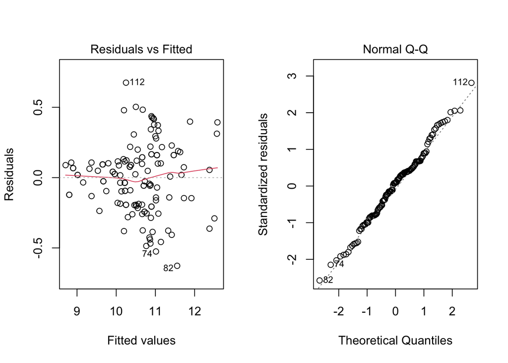

```r
par(mfrow = c(1,2))
plot(model1,1)
plot(model1,2)
```

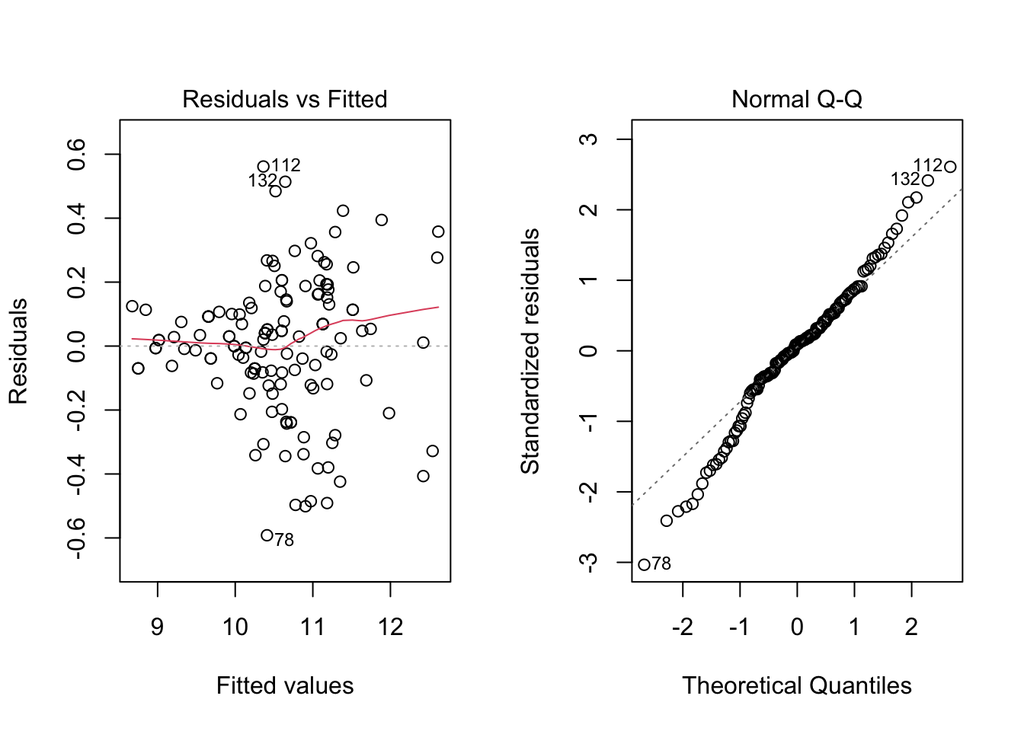

```r
par(mfrow = c(1,2))
plot(model2,1)
plot(model2,2)
```

The model diagnostic plots above show that the model is passable. There is good scatter of the residuals around zero for the range of fitted values (the mean value of the residuals is, in fact, zero). The residuals Q-Q plot shows a pretty normal distribution. Overall, the evidence points toward the model 1 being valid.

```r
lev<-hatvalues(model1)[hatvalues(model1)>2*(length(coef(model1))/length(hatvalues(model1)))]
out<-rstandard(model1)[abs(rstandard(model1)) > 2]
cd<-cooks.distance(model1)[cooks.distance(model1) >4/length(cooks.distance(model1))]
leve<-as.integer(names(lev))
oute<-as.integer(names(out))
cde<-as.integer(names(cd))
intersect(leve, oute)
```

```
## [1] 117
```

```r
intersect(oute,cde)
```

```
## [1]  82 110 112 117 132
```

```r
intersect(cde,leve)
```

```
## [1]  78 117
```

```r
intersect(intersect(cde,leve), oute)
```

```
## [1] 117
```

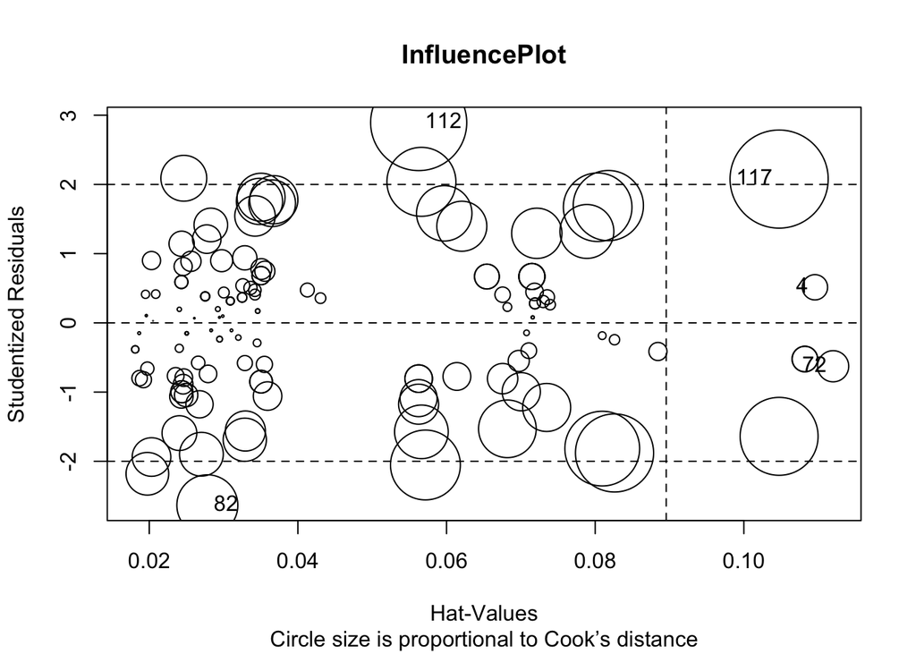

```
##        StudRes        Hat       CookD
## 4    0.5141837 0.10956306 0.005453175
## 72  -0.6267818 0.11200807 0.008298255
## 82  -2.6352458 0.02781579 0.031645999
## 112  2.8937403 0.05624898 0.078650346
## 117  2.0771741 0.10474257 0.082009970
```

```r
influencePlot(model1, id.method="identify", main="InfluencePlot",sub="Circle size is proportional to Cook’s distance")
```

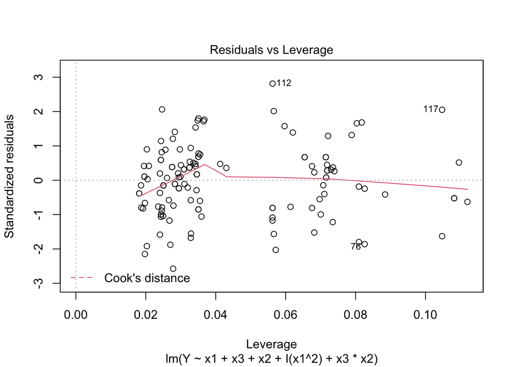

```r
plot(model1, which=5)
```

According to the analysis of the leverage, outlier and influential the obeservation 4,72,82,112,117 were removed.

```r
df2=df[-c( 4,72,82,112,117),]
model11=lm(Y~  x1 +  x3   +   x2   + I(x1^2)  +  x3*x2 ,data=df2)
summary(model11)
```

```
##
## Call:
## lm(formula = Y ~ x1 + x3 + x2 + I(x1^2) + x3 * x2, data = df2)
##
## Residuals:
##     Min      1Q  Median      3Q     Max
## -0.5322 -0.1622  0.0201  0.1341  0.5392
##
## Coefficients:
##              Estimate Std. Error t value Pr(>|t|)
## (Intercept) 12.830464   0.076901 166.844  < 2e-16 ***
## x1          -0.815110   0.045350 -17.974  < 2e-16 ***
## x3          -0.723046   0.058312 -12.400  < 2e-16 ***
## x2          -0.031890   0.003358  -9.498 2.22e-16 ***
## I(x1^2)      0.081185   0.006748  12.032  < 2e-16 ***
## x3:x2       -0.025531   0.004802  -5.317 4.80e-07 ***
## ---
## Signif. codes:  0 '***' 0.001 '**' 0.01 '*' 0.05 '.' 0.1 ' ' 1
##
## Residual standard error: 0.2314 on 123 degrees of freedom
## Multiple R-squared:  0.9254, Adjusted R-squared:  0.9224
## F-statistic: 305.3 on 5 and 123 DF,  p-value: < 2.2e-16
```

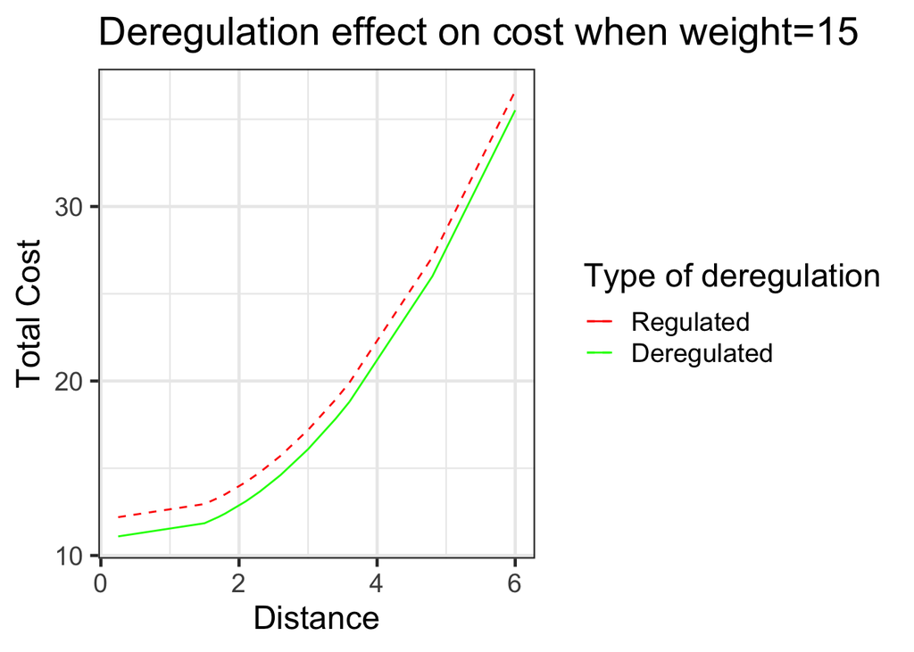

```r
y0=12.35-0.815*df2$x1+0.81*df2$x1^2
y1=12.35-0.815*df2$x1+0.81*df2$x1^2-1.1025
ggplot(df2, aes(x1)) +                    # basic graphical object
  geom_line(aes(y=y0,  colour="red"), linetype = "dashed") +  # first layer
  geom_line(aes(y=y1, colour="green")) + # second layer
  xlab("Distance") +
  ylab("Total Cost") +
  ggtitle("Deregulation effect on cost when weight=15") +
  theme_bw(base_size=18) +
  scale_color_identity(name = "Type of deregulation",
                          breaks = c("red", "green"),
                          labels = c("Regulated", "Deregulated"),
                          guide = "legend")
```

Finally the above graph illustrated that because of the fact that red line (before deregulazation) is placed higher than green one (after deregulazation), we can concluse that deregulation was ables to decrease the total xost of transportation